# nimbleFunction programming example: Reversible jump

ENVR Asheville workshop short course

NIMBLE Development Team

# Introduction

Here we'll program another sampler using nimbleFunctions, this time applying reversible jump (RJ) MCMC for variable selection in the parametric Avandia model example. The nice thing about RJ for variable selection is that it is a fairly straightforward implementation of RJ.

# BUGS code for reversible jump version of parametric Avandia model

Here's the BUGS code that implements the model specified earlier, modified slightly to allow for variable selection by adding an indicator that will "turn on" or "turn off" the Avandia effect.

```r
codeParamSel <- nimbleCode({
    for(i in 1:nStudies) {
        y[i] ~ dbin(size = m[i], prob = q[i]) # avandia MIs
        x[i] ~ dbin(size = n[i], prob = p[i]) # control MIs
        q[i] <- expit(theta*indic + gamma[i]) # Avandia log-odds
        p[i] <- expit(gamma[i])               # control log-odds
        gamma[i] ~ dnorm(mu, sd = tau)        # study effects
    }
    theta ~ dflat()        # effect of Avandia
    # random effects hyperparameters
    mu ~ dflat()
    tau ~ dunif(0, 100)
    indic ~ dbern(0.5)             ## turns theta on and off
})
```

# Overall strategy for variable selection via RJ

We won't go into all the details, but by looking at the rules for how to set up a valid RJ sampler, one can see that in the simple variable selection case, they simplify to straightforward calculations.

# RJ sampler setup code

The RJ sampler will operate on the indicator of whether questionable variable is in the model or not, since that indicator is what changes the model dimension.

The setup code needs to determine the nodes involved in the full model and the reduced model, where the reduced model omits the variable under consideration.

```r
 setup = function( model, mvSaved, target, control ) {
   # target = 'indic'
   coefNode <- control$coef   # e.g., 'theta'
   scale    <- control$scale  # could be made adaptive
   # with variable
   calcNodes_full <- model$getDependencies(c(coefNode, target))
   # without variable
   calcNodes_reduced <- model$getDependencies(target)
 }
```

# RJ sampler run code

Depending on the current value of the variable selection indicator, we use the reversible jump calculations to propose either including or excluding the variable from the model.

```r
run = function( ) {  # Reversible-jump updates:
   currentIndicator <- model[[target]]
   if(currentIndicator == 0) { ## propose adding theta to model
     currentLogProb <- model$getLogProb(calcNodes_reduced)
     proposalCoef <- rnorm(1, 0, sd = scale)
     model[[target]] <<- 1      # put proposal values in model
     model[[coefNode]] <<- proposalCoef
     logProbForwardProposal <-
                dnorm(proposalCoef, 0, sd = scale, log = TRUE)
     proposalLogProb <- model$calculate(calcNodes_full)
     logAcceptProb <- proposalLogProb -
                        currentLogProb -
                        logProbForwardProposal
   } else {                   ## propose removing z2
     currentLogProb <- model$getLogProb(calcNodes_full)
     currentCoef <- model[[coefNode]]      # get current theta
     logProbReverseProposal <-
                 dnorm(currentCoef, 0, sd = scale, log = TRUE)
     model[[target]] <<- 0      # put proposal values in model
     model[[coefNode]] <<- 0
     model$calculate(calcNodes_full) # calculate proposal log probabilities
     logAcceptProb <- model$getLogProb(calcNodes_reduced) -
                        currentLogProb +
                        logProbReverseProposal
   }
   ## additional book-keeping code to go here
}
```

# The full RJ sampler

Putting it all together, here is the full code for our RJ variable selection sampler.

```r
RJ_var_sel <- nimbleFunction(
 contains = sampler_BASE,
 setup = function( model, mvSaved, target, control ) {
   # target = 'indic'
   coefNode <- control$coef
   scale    <- control$scale  # could be made adaptive
   # with variable
   calcNodes_full <- model$getDependencies(c(coefNode, target))
   # without variable (don't calculate prior for coefNode since not in model)
   calcNodes_reduced <- model$getDependencies(target)
 },
run = function( ) {  # Reversible-jump updates:
   currentIndicator <- model[[target]]
   if(currentIndicator == 0) { ## propose adding theta to model
     currentLogProb <- model$getLogProb(calcNodes_reduced)
     proposalCoef <- rnorm(1, 0, sd = scale)
     model[[target]] <<- 1
     model[[coefNode]] <<- proposalCoef
     logProbForwardProposal <-
                dnorm(proposalCoef, 0, sd = scale, log = TRUE)
     proposalLogProb <- model$calculate(calcNodes_full)
     logAcceptProb <- proposalLogProb -
                        currentLogProb -
                        logProbForwardProposal
   } else {                   ## propose removing theta
     currentLogProb <- model$getLogProb(calcNodes_full)
     currentCoef <- model[[coefNode]]
     logProbReverseProposal <-
                 dnorm(currentCoef, 0, sd = scale, log = TRUE)
     model[[target]] <<- 0
     model[[coefNode]] <<- 0
     model$calculate(calcNodes_full) # calculate proposal log probabilities
     logAcceptProb <- model$getLogProb(calcNodes_reduced) -
                        currentLogProb +
                        logProbReverseProposal
    }
    accept <- decide(logAcceptProb)
    if(accept) {
      copy(from = model, to = mvSaved, row = 1,
         nodes = calcNodes_full, logProb = TRUE)
    } else {
      copy(from = mvSaved, to = model, row = 1,
         nodes = calcNodes_full, logProb = TRUE)
    }
 },
 methods = list(reset = function() {
 })
)
```

# Final modification: Turning off sampling when the covariate is not in the model

Here we'll create a sampler that simply wraps around our usual slice sampler. Note that in setup code we can create instances of other nimbleFunctions and then use these in the run code.

```r
slice_var_sel_wrapper <- nimbleFunction(
    contains = sampler_BASE,
    setup = function(model, mvSaved, target, control) {
        regular_slice_sampler <- sampler_slice(model, mvSaved, target = target,
                                         control = control$sliceControl)
        indicatorNode <- control$indicator
    },
    run = function() {
        if(model[[indicatorNode]] == 1) regular_slice_sampler$run()
    },
    methods = list(
        reset = function() {regular_slice_sampler$reset()}
    ))
```

# Running the MCMC

Now let's run the MCMC. We'll need to manually assign our special samplers for the RJ aspect of things.

```r
dat <- read.csv('avandia.csv')
dat <- dat[-49, ]

x <- dat$controlMI
n <- dat$nControl
y <- dat$avandiaMI
m <- dat$nAvandia

nStudies <- nrow(dat)
data <- list(x = x, y = y)
constants = list(n = n, m = m, nStudies = nStudies)

inits = list(theta = 0, mu = 0, tau = 1, gamma = rnorm(nStudies), indic = 1)

modelParamSel <- nimbleModel(code = codeParamSel, data = data, inits = inits,
                      constants = constants)
```

```
## defining model...
```

```
## building model...
```

```
## setting data and initial values...
```

```
## running calculate on model (any error reports that follow may simply reflect missing values in model variables) ...
## checking model sizes and dimensions...
## model building finished.
```

```r
cModelParamSel = compileNimble(modelParamSel)
```

```
## compiling... this may take a minute. Use 'showCompilerOutput = TRUE' to see C++ compiler details.
## compilation finished.
```

```r
conf <- configureMCMC(modelParamSel, thin = 10, monitors = c('theta', 'indic'))
conf$removeSamplers(c('theta', 'indic'))
## special changes for variable selection:
conf$addSampler('indic', 'RJ_var_sel', control = list(coef = 'theta', scale = 0.5))
conf$addSampler('theta', 'slice_var_sel_wrapper', control = list(indicator = 'indic'))

mcmc <- buildMCMC(conf)
cmcmc <- compileNimble(mcmc, project = modelParamSel)
```

```
## compiling... this may take a minute. Use 'showCompilerOutput = TRUE' to see C++ compiler details.
## compilation finished.
```

```r
samples <- runMCMC(cmcmc, niter = 11000, nburnin = 1000)
```

```
## runMCMC's handling of nburnin changed in nimble version 0.6-11. Previously, nburnin samples were discarded *post-thinning*.  Now nburnin samples are discarded *pre-thinning*.  The number of samples returned will be floor((niter-nburnin)/thin).
## running chain 1...
```

```
## |-------------|-------------|-------------|-------------|
## |-------------------------------------------------------|
```

Let's look at the MCMC behavior of the indicator and of the coefficient of interest.

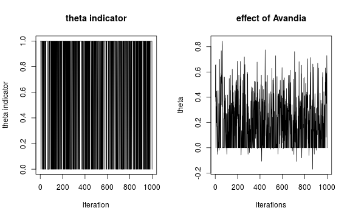

```r
par(mfrow = c(1,2))
ts.plot(samples[ , 'indic'], xlab = 'iteration', ylab = 'theta indicator',
                    main = 'theta indicator')
ts.plot(samples[ , 'theta'], xlab = 'iterations', ylab = 'theta',
               main = 'effect of Avandia')
```

```r
## posterior probability of inclusion
mean(samples[ , 'indic'])
```

```
## [1] 0.651
```

That's less strong evidence for an Avandia effect than I interpreted based on the posterior from module 9...